# Individual 2

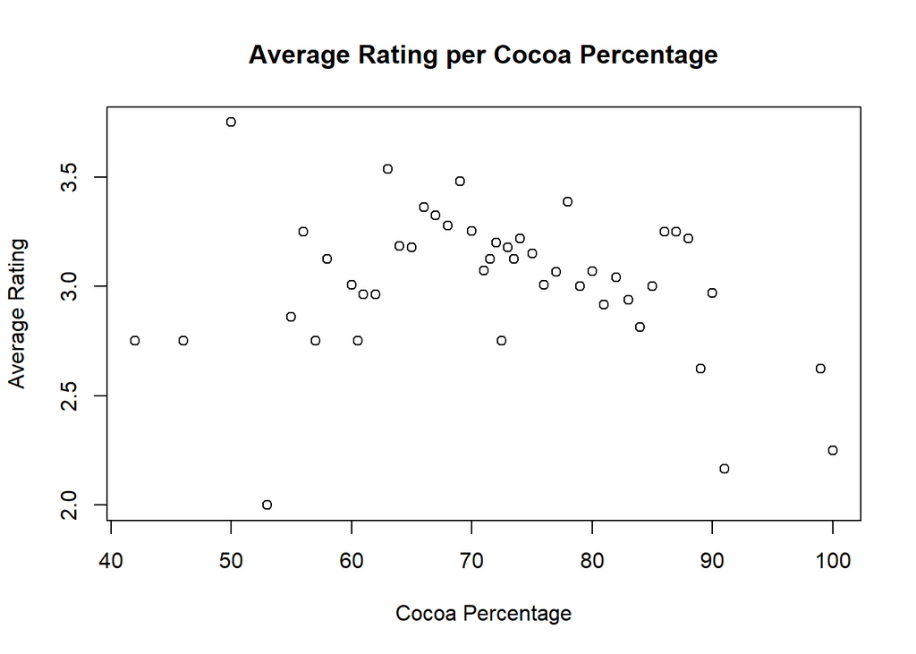

   ```r
     plot(ratingsByCacaoPerc$Cocoa_Percent, ratingsByCacaoPerc$Rating, xlab = 'Cocoa Percentage', ylab = 'Average Rating', main = 'Average Rating per Cocoa Percentage')
   ```

   ```r
     cor(ratingsByCacaoPerc$Cocoa_Percent, ratingsByCacaoPerc$Rating)
   ```

   ```
   ## [1] -0.1784699
   ```

   From the numerical summeries, you can start to see that the average doesn’t really seem to depend on the cocoa percentage of the chocolate bar. There’s a good mix of bars with a lower cocoa percentage having a higher average rating and vice versa. From the scatter plot you can really see this. Even as the cocoa percentage increases, the average rating is usually between 2.5 and 3.5. Finally, below the scatterplot, the correlation efficient between cocoa percentage and average rating is -0.178, which means that there is a very weak correlation between the two.
4. How do different characteristics of the chocolate compare? To elaborate, which characteristics tend to be more favorable and which ones are not? Create both numerical and graphical summaries, and explain.

   ```r
     ratingsByCharacteristic <- aggregate(Rating ~ Characteristics1, data = choco, mean)
     ratingsByCharacteristicSorted <- ratingsByCharacteristic[order(ratingsByCharacteristic$Rating), ]
     ratingsByCharacteristicSorted
   ```

   ```
   ##                   Characteristics1   Rating
   ## 414          this is not chocolate 1.000000
   ## 68                        chemical 1.500000
   ## 169          high intensity bitter 1.500000
   ## 195                         klingy 1.500000
   ## 432                     very nutty 1.750000
   ## 26            bitter coffee flavor 2.000000
   ## 129                     fresh nibs 2.000000
   ## 210                        malitol 2.000000
   ## 256           multiple off flavors 2.000000
   ## 261                   non descript 2.000000
   ## 327                      sandpaper 2.000000
   ## 362                     some fruit 2.000000
   ## 50                  burnt up front 2.250000
   ## 123                extremely sweet 2.250000
   ```

   [output cut: 436 more lines]

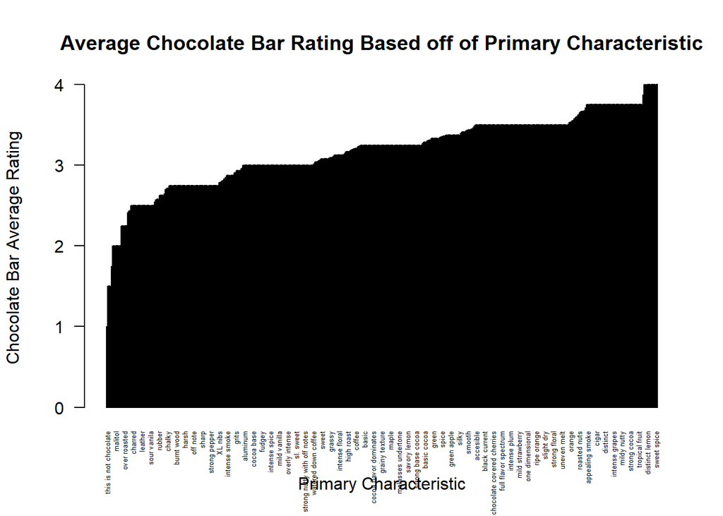

   ```r
     barplot(ratingsByCharacteristicSorted$Rating, xlab = 'Primary Characteristic', ylab = 'Chocolate Bar Average Rating', main = 'Average Chocolate Bar Rating Based off of Primary Characteristic', las = 2, names.arg = ratingsByCharacteristicSorted$Characteristics1, cex.names = 0.4)
   ```

   From the left, you can see that malitol, over roasted, charred, and leather are some of the least favorable primary characteristics. On the other hand, Sweet spice, distinct lemon, tropical fruit, and strong cocoa are the most favored primary characteristics. Looking at the numerical data above the chart, you get a better look into which primary characteristics are prefered/not preferred since the graph cannot display all of the names.
5. I would like to find out which countries produce the best bars and I would like to find out what company produces the best chocolate bars

   ```r
     ratingsByCountry <- aggregate(Rating ~ Location, data = choco, mean)
     ratingsByCountry
   ```

   ```
   ##                 Location   Rating
   ## 1              Amsterdam 3.312500
   ## 2              Argentina 3.305556
   ## 3              Australia 3.358491
   ## 4                Austria 3.258333
   ## 5                Belgium 3.105932
   ## 6                Bolivia 3.250000
   ## 7                 Brazil 3.281250
   ## 8                 Canada 3.301242
   ## 9                  Chile 3.750000
   ## 10              Colombia 3.160000
   ## 11            Costa Rica 3.138889
   ## 12        Czech Republic 3.000000
   ## 13               Denmark 3.338710
   ## 14    Dominican Republic 3.122727
   ```

   [output cut: 53 more lines]

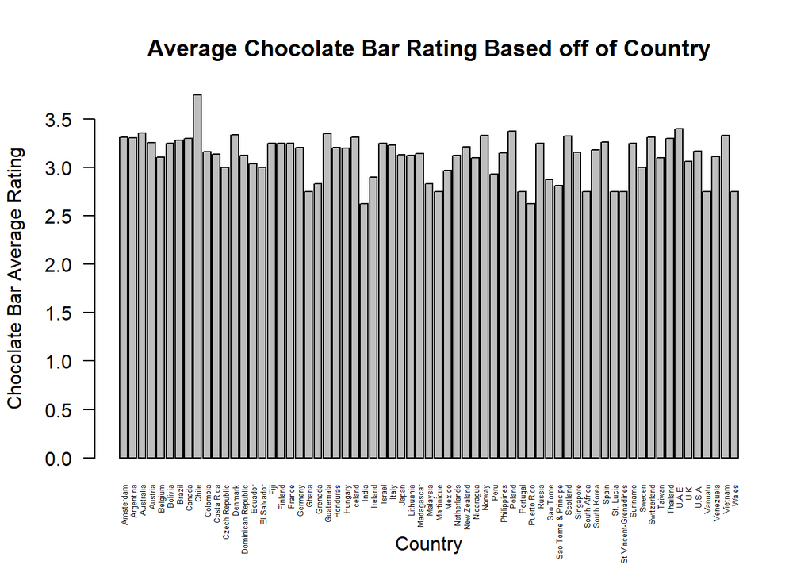

   ```r
     barplot(ratingsByCountry$Rating, xlab = 'Country', ylab = 'Chocolate Bar Average Rating', main = 'Average Chocolate Bar Rating Based off of Country', las = 2, names.arg = ratingsByCountry$Location, cex.names = 0.4)
   ```

   ```r
     ratingsByCompany <- aggregate(Rating ~ Company, data = choco, mean)
     ratingsByCompany
   ```

   ```
   ##                                     Company   Rating
   ## 1                                      5150 3.500000
   ## 2                                  A. Morin 3.400000
   ## 3                                    Acalli 3.562500
   ## 4             Adi aka Fijiana (Easy In Ltd) 3.250000
   ## 5                                     Aelan 2.750000
   ## 6                        Aequare (Gianduja) 2.875000
   ## 7                                  Ah Cacao 3.000000
   ## 8                        Akesson's (Pralus) 3.083333
   ## 9                             Alain Ducasse 2.833333
   ## 10                                Alexandre 3.500000
   ## 11                    Altus aka Cao Artisan 2.863636
   ## 12                                    Amano 3.416667
   ## 13                    Amatller (Simon Coll) 2.875000
   ## 14                            Amazing Cacao 3.250000
   ```

   [output cut: 527 more lines]

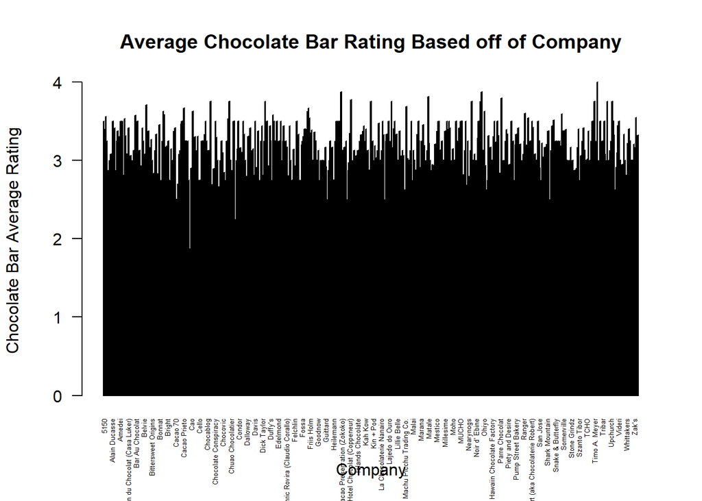

   ```r
     barplot(ratingsByCompany$Rating, xlab = 'Company', ylab = 'Chocolate Bar Average Rating', main = 'Average Chocolate Bar Rating Based off of Company', las = 2, names.arg = ratingsByCompany$Company, cex.names = 0.4)
   ```

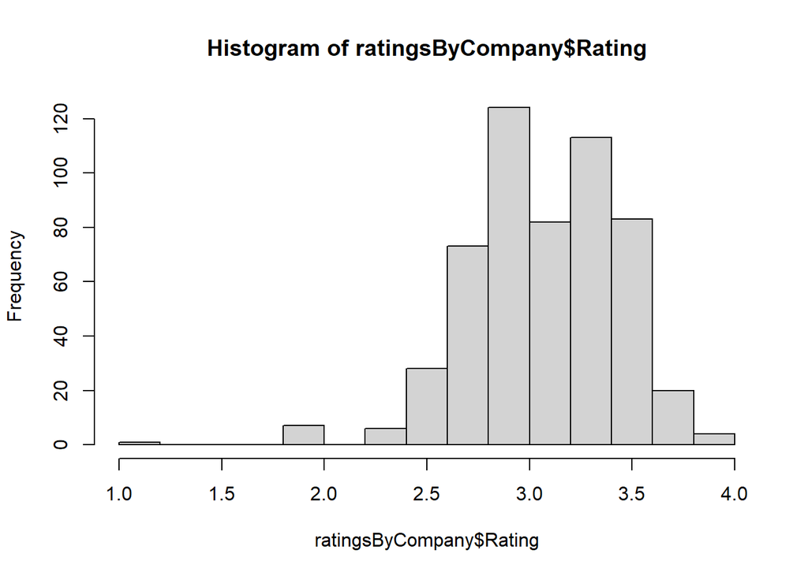

   ```r
     hist(ratingsByCompany$Rating)
   ```

   Although there a lot of companies and it is not easy to see individual companies in the barchart, it obvious that there is a wide range of ratings. The histogram also confirms this with spikes from ~2.5 - ~3.75.